# Programmer vs Developer Marriage

On the ACCU listserve, Derek Jones recently asked:

> Why are the married partner’s occupation of Computer programmers and Software developers so different? https://flowingdata.com/2021/05/26/jobs-that-marry-together/

> Is Computer programmer a government job, and Software developer an industrial one in the US?

I’ve decided to take a stab at answering this question:

Flowing Data is using data from the 2015 ACS survey, which uses a has of standardized job codes managed by the Bureau of Labor Statistics. They are different from how I would use those job titles colloquially, but the data set is widely used.

See https://www.bls.gov/soc/2018/major_groups.htm#15-0000

quote:

> *15-1251* Computer Programmers

> Create, modify, and test the code and scripts that allow computer applications to run. Work from specifications drawn up by software and web developers or other individuals. May develop and write computer programs to store, locate, and retrieve specific documents, data, and information.

> Illustrative examples: Applications Programmer , Computer Language Coder , IT Programmer , Systems Programmer

and

> *15-1252* Software Developers

> Research, design, and develop computer and network software or specialized utility programs. Analyze user needs and develop software solutions, applying principles and techniques of computer science, engineering, and mathematical analysis. Update software or enhance existing software capabilities. May work with computer hardware engineers to integrate hardware and software systems, and develop specifications and performance requirements. May maintain databases within an application area, working individually or coordinating database development as part of a team.

> Illustrative examples: Computer Applications Engineer , Computer Systems Engineer , Mobile Applications Developer , Software Applications Architect , Software Engineer , Systems Software Developer

Anyways, we can download microdata from https://usa.ipums.org/usa/ and take a looksee.

```r
# Below provided by IPUMS to load data
# NOTE: To load data, you must download both the extract's data and the DDI
# and also set the working directory to the folder with these files (or change the path below).

library(ipumsr)

ddi <- read_ipums_ddi("usa_00002.xml")
data <- read_ipums_micro(ddi)
```

```
## Use of data from IPUMS USA is subject to conditions including that users should
## cite the data appropriately. Use command `ipums_conditions()` for more details.
```

And set it up for survey weighting:

```r
require(survey)
dsgn <- svydesign(data=data, ids =~0,   weights = ~PERWT)
prog_dsgn <- subset(dsgn, OCCSOC %in% c("151251", "151252"))
```

## Age diff

Below, we can plot the age distribution of the two different job codes.

Two things are interesting:

- “developers” are much more concentrated in the 25-37 range
- “programmers” have a chunk in the <25 range
- “programmers” also is a flatter distribution, more in the 50-60 range

```r
require(reshape2)
```

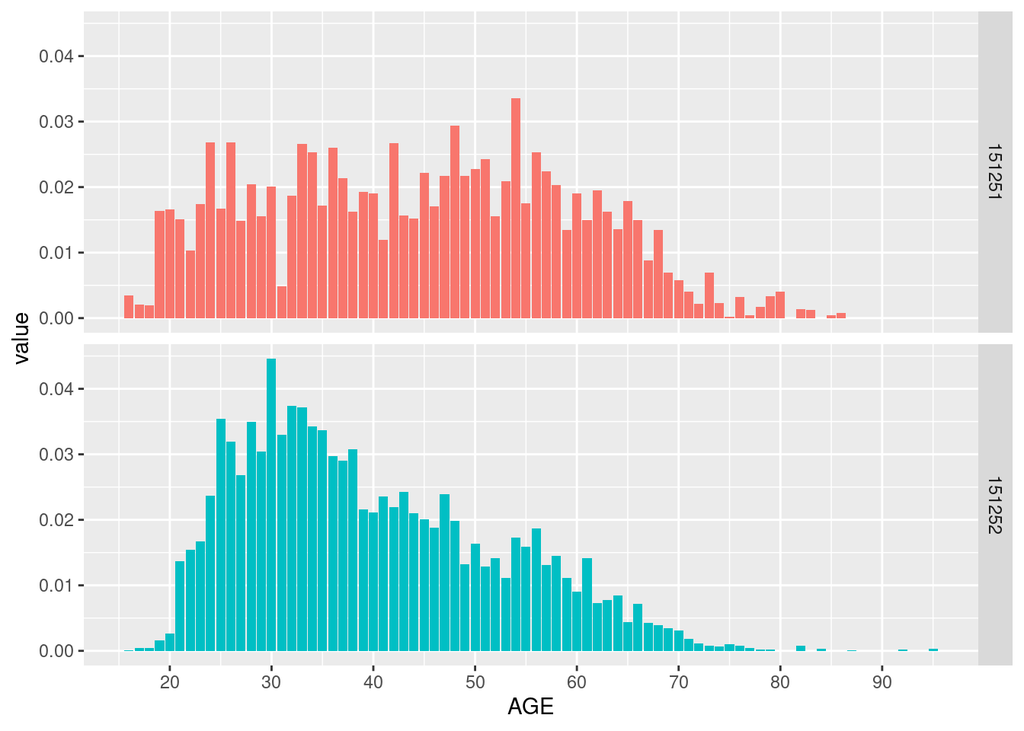

```r
require(ggplot2)
age.dist <- svytable(~OCCSOC+AGE, prog_dsgn) |> prop.table(margin=1) |> melt()


ggplot(age.dist) + aes(x=AGE, y=value, fill=OCCSOC|> as.factor() ) + geom_col() + facet_grid(OCCSOC~.) + scale_fill_discrete(guide=NULL) + scale_x_continuous(breaks=seq(0,100, 10))
```

## EDUC diff

Also of note:

- “programmer” has more Highschool / partial college
- “developer” has more 4 years of college and a lot more 5+ years.

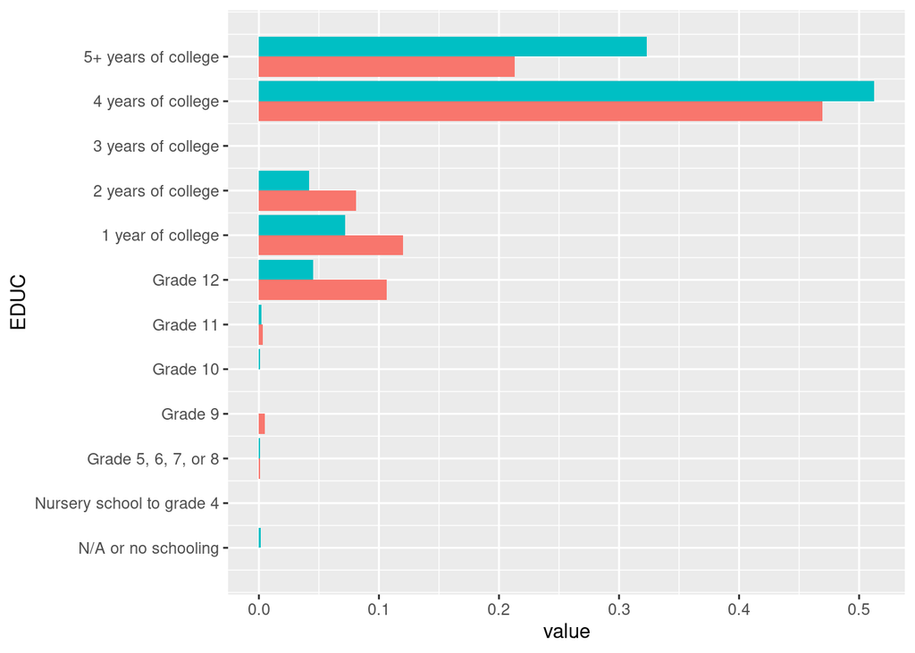

```r
educ.dist <- svytable(~OCCSOC+EDUC, prog_dsgn) |> prop.table(margin=1) |> melt()


ggplot(educ.dist) + aes(x=EDUC, y=value, fill=OCCSOC|> as.factor() ) + geom_col(position = "dodge") + scale_fill_discrete(guide=NULL) + scale_x_continuous(breaks=attr(data$EDUC, "labels")) + coord_flip()
```

## Gender diff

Commenting out, not interesting…

```r
# gender.dist <- svytable(~OCCSOC+SEX, prog_dsgn) |> prop.table(margin=1) |> melt()
#
#
#ggplot(gender.dist) + aes(x=factor(SEX, 1:2, c("M", "F")), y=value, fill=OCCSOC|> as.factor() ) + geom_col(position = "dodge") + xlab("GENDER") + scale_fill_discrete(guide=NULL)
```

## Citations

> Steven Ruggles, Sarah Flood, Sophia Foster, Ronald Goeken, Jose Pacas, Megan Schouweiler and Matthew Sobek. IPUMS USA: Version 11.0 [dataset]. Minneapolis, MN: IPUMS, 2021. https://doi.org/10.18128/D010.V11.0